# Weight Lifting Exercise Prediction

Barrett W Nuzum

January 28, 2016

# Synopsis

The following is an effort to use Machine Learning on a portion of the HAR “Weight Lifting Exercise” dataset (herein WLED) to create a model to predict the “classe” outcome for a test set of the data, prepared by the instructors.

By using sensor data, can we predict how well the exercise was performed?

# What’s in the data?

The first question – What the heck is the “Classe” outcome?

According to the documentation[^1], “Six young health participants were asked to perform one set of 10 repetitions of the Unilateral Dumbbell Biceps Curl in five different fashions: exactly according to the specification (Class A), throwing the elbows to the front (Class B), lifting the dumbbell only halfway (Class C), lowering the dumbbell only halfway (Class D) and throwing the hips to the front (Class E).”

Let’s start by loading in useful packages and the training data.

```r
packages <- c('plyr', 'dplyr', 'caret', 'kernlab', 'e1071','AppliedPredictiveModeling', 'rattle', 'rpart', 'rpart.plot', 'gmodels')
for (package in packages) {
        if (!require(package, character.only=T, quietly=T)) {
                install.packages(package, repos="http://cran.us.r-project.org")
                library(package, character.only=T)
        }
}

set.seed(8012) # A specific seed limits the randomness of random numbers retrieved and will help reproducibility.

training <- read.csv('pml-training.csv', na.strings=c("NA","NaN", " ", "#DIV/0", ""))
```

Note that there are many, many variables in the dataset. Let’s see just how many.

```r
colnames(training)
```

```
##   [1] "X"                        "user_name"
##   [3] "raw_timestamp_part_1"     "raw_timestamp_part_2"
##   [5] "cvtd_timestamp"           "new_window"
##   [7] "num_window"               "roll_belt"
##   [9] "pitch_belt"               "yaw_belt"
##  [11] "total_accel_belt"         "kurtosis_roll_belt"
##  [13] "kurtosis_picth_belt"      "kurtosis_yaw_belt"
##  [15] "skewness_roll_belt"       "skewness_roll_belt.1"
##  [17] "skewness_yaw_belt"        "max_roll_belt"
##  [19] "max_picth_belt"           "max_yaw_belt"
##  [21] "min_roll_belt"            "min_pitch_belt"
##  [23] "min_yaw_belt"             "amplitude_roll_belt"
##  [25] "amplitude_pitch_belt"     "amplitude_yaw_belt"
##  [27] "var_total_accel_belt"     "avg_roll_belt"
##  [29] "stddev_roll_belt"         "var_roll_belt"
```

[output cut: 65 more lines]

Wow.

# Cleaning up the Data

We begin by removing some variables that are clearly not of use.

```r
training <- training %>% select(-X, -user_name, -raw_timestamp_part_1, -raw_timestamp_part_2, -cvtd_timestamp, -new_window, -num_window)
```

Many of the variables are filled with NAs that will slow down automated feature selection.  
Let’s go through all the columns and all the rows and if any one column is more than, say, 30% NAs, let’s remove the column completely.

```r
ncol(training)
```

```
## [1] 153
```

```r
target <- nrow(training)
threshold <- round( target * 0.3 )
training2 <- training[, colSums(is.na(training))< threshold]
ncol(training2)
```

```
## [1] 53
```

Now, lets partition our data into a Training Set and a Test Set.

```r
inMyTrain<- createDataPartition(y=training2$classe, p=0.7, list=FALSE)
myTrain <- training2[inMyTrain,]
myTesting <- training2[-inMyTrain,]
```

# Training Models

Many of the model methods in caret will perform automated feature selection. We then try to see if they can handle this many variables.

Let’s try a Stochastic Gradient Boosting model.

```r
# We'll use Repeated k-fold Cross-Validation
train_control <- trainControl(method="repeatedcv", number=10, repeats=3)

fit.gbm.rcv <- train(classe ~ ., data = myTrain,
                 trControl = train_control,
                 method = "gbm",
                 verbose = FALSE)
```

Let’s see if Random Forest gives us a better result.

```r
fit.rf.cv <- train(classe ~ ., data = myTrain,
                 trControl = train_control,
                 method='rf', verbose=TRUE)
```

# Comparing Models

Let’s see which variables each model found important.

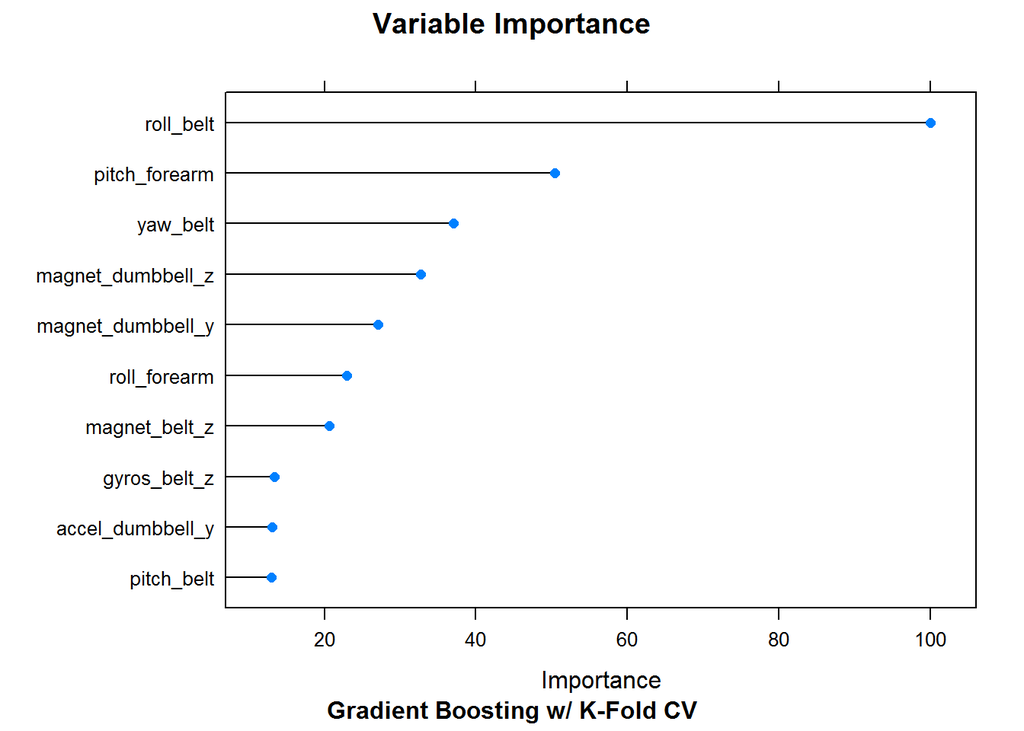

```r
varImps <- varImp(fit.gbm.rcv, 10)
plot(varImps, top = 10, main = 'Variable Importance', sub = 'Gradient Boosting w/ K-Fold CV')
```

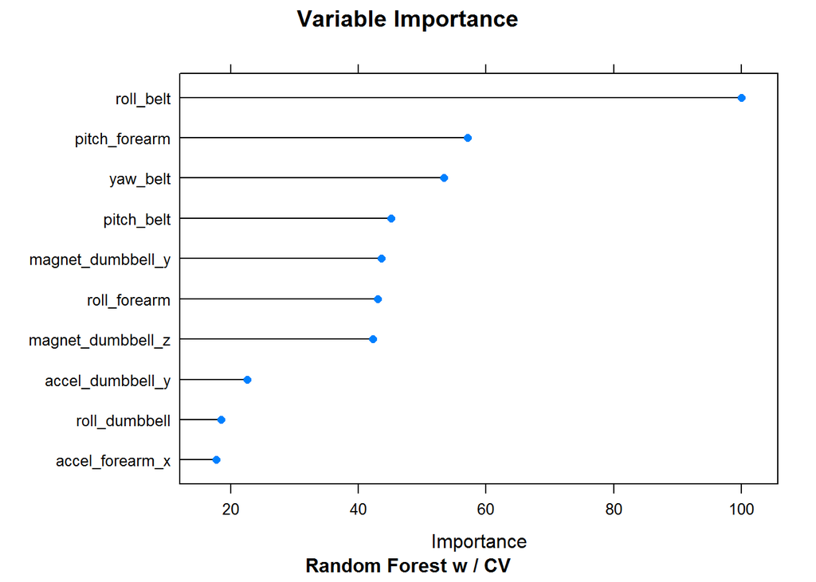

```r
rf.varImps <- varImp(fit.rf.cv, 10)
plot(rf.varImps, top = 10, main = 'Variable Importance', sub = 'Random Forest w / CV')
```

We compare predictions from each model against our test set.

```r
gbmFitResults <- confusionMatrix(
    predict(fit.gbm.rcv, newdata=myTesting),
    myTesting$classe
)
rfFitResults <- confusionMatrix(
    predict(fit.rf.cv, newdata=myTesting),
    myTesting$classe
)
```

Confusion Matrices will compare our predictions against the actual values found in the test set.

```r
# Stochastic Gradient Boosting Confusion Matrix
gbmFitResults$table
```

```
##           Reference
## Prediction    A    B    C    D    E
##          A 1649   40    0    0    2
##          B   17 1062   30    0    9
##          C    3   33  986   40    6
##          D    3    4   10  921   14
##          E    2    0    0    3 1051
```

```r
# Random Forest Confusion Matrix
rfFitResults$table
```

```
##           Reference
## Prediction    A    B    C    D    E
##          A 1673   14    0    0    0
##          B    0 1120    5    1    0
##          C    0    5 1020   16    2
##          D    0    0    1  947    1
##          E    1    0    0    0 1079
```

```r
# Stochastic Gradient Boosting By Class
gbmFitResults$byClass
```

```
##          Sensitivity Specificity Pos Pred Value Neg Pred Value Prevalence
## Class: A   0.9850657   0.9900261      0.9751626      0.9940391  0.2844520
## Class: B   0.9323968   0.9882006      0.9499106      0.9838473  0.1935429
## Class: C   0.9610136   0.9831241      0.9232210      0.9916961  0.1743415
## Class: D   0.9553942   0.9937005      0.9674370      0.9912832  0.1638063
## Class: E   0.9713494   0.9989590      0.9952652      0.9935805  0.1838573
##          Detection Rate Detection Prevalence Balanced Accuracy
## Class: A      0.2802039            0.2873407         0.9875459
## Class: B      0.1804588            0.1899745         0.9602987
## Class: C      0.1675446            0.1814783         0.9720689
## Class: D      0.1564996            0.1617672         0.9745473
## Class: E      0.1785896            0.1794393         0.9851542
```

```r
# Random Forest Results By Class
rfFitResults$byClass
```

```
##          Sensitivity Specificity Pos Pred Value Neg Pred Value Prevalence
## Class: A   0.9994026   0.9966754      0.9917012      0.9997618  0.2844520
## Class: B   0.9833187   0.9987358      0.9946714      0.9960076  0.1935429
## Class: C   0.9941520   0.9952665      0.9779482      0.9987608  0.1743415
## Class: D   0.9823651   0.9995936      0.9978925      0.9965559  0.1638063
## Class: E   0.9972274   0.9997918      0.9990741      0.9993757  0.1838573
##          Detection Rate Detection Prevalence Balanced Accuracy
## Class: A      0.2842821            0.2866610         0.9980390
## Class: B      0.1903144            0.1913339         0.9910272
## Class: C      0.1733220            0.1772302         0.9947093
## Class: D      0.1609176            0.1612574         0.9909794
## Class: E      0.1833475            0.1835174         0.9985096
```

```r
overallRFfit <- data.frame(as.list(rfFitResults$overall)) %>% mutate(method = 'Random Forest')
overallGBMfit <- data.frame(as.list(gbmFitResults$overall)) %>% mutate(method = 'Gradient Boosting')
rbind(overallRFfit, overallGBMfit) %>% select(method, Accuracy, Kappa, AccuracyLower, AccuracyUpper, AccuracyNull)
```

```
##              method  Accuracy     Kappa AccuracyLower AccuracyUpper
## 1     Random Forest 0.9921835 0.9901104     0.9895875     0.9942718
## 2 Gradient Boosting 0.9632965 0.9535615     0.9581722     0.9679546
##   AccuracyNull
## 1     0.284452
## 2     0.284452
```

# Conclusion

The Random Forest method is a good choice to predict class values in this model.

[^1]: Velloso, E.; Bulling, A.; Gellersen, H.; Ugulino, W.; Fuks, H. Qualitative Activity Recognition of Weight Lifting Exercises. Proceedings of 4th International Conference in Cooperation with SIGCHI (Augmented Human ’13) . Stuttgart, Germany: ACM SIGCHI, 2013. http://groupware.les.inf.puc-rio.br/har#ixzz3yrZlHHgQ